# **Asignatura:** Investigación en Inteligencia Artificial!!

### Trabajo: Introducción a Python y procesamiento de datos con Python

## Primera parte: Introducción a la programación con Python

**1. Crea una función en Python que calcule el máximo común divisor de dos números.**

> *El MCD es el máximo número entero que divide un conjunto de dos o más números enteros sin dejar residuo.*

Definimos la función mcd

```python
# define la función mcd
def mcd(a, b):
    resto = 0
    while(b > 0):
        resto = b
        b = a % b
        a = resto
    return a
```

Solicitamos los 2 valores y calcualmos el resultado.

```python
num1 = int(input("Introduce el primer numero: "))
num2 = int(input("Introduce el segundo numero: "))
print("El máximo común divisor de ", num1," y ", num2," es ", mcd(num1, num2))
```

```
El máximo común divisor de  3  y  4  es  1
```

**2. Crea una función en Python que calcule el mínimo común múltiplo de dos números.**

> *El MCM Es el menor número natural distinto de cero que es múltiplo común de un conjunto de 2 o más números naturales*

```python
# define la función gcd (recursiva) y mcm
def gcd(x, y):
    return x if not y else gcd(y, x % y)

def mcm(x, y):
    return x * y / gcd(x, y)
```

Solicitamos los 2 valores y calcualmos el resultado.

```python
num1 = int(input("Introduce el primer numero: "))
num2 = int(input("Introduce el segundo numero: "))
print("El minimo comun multiplo de ", num1," y ", num2," es ", mcm(num1, num2))
```

```
El minimo comun multiplo de  3  y  3  es  3.0
```

**3. Basándote en datos aleatorios (los que quieras) crea un gráfico de tarta (pie chart) con Mapplotlib.**

En el siguiente grafico, mostramos un grafico de pia, que indica el porcentaje de carreras más demandas en las universidades el año 2020. Ojo datos random, no son reales.

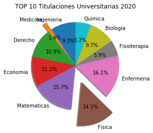

```python
import matplotlib.pyplot as plt
import numpy as np

def rdm():
    r = np.random.random(1) *100
    return r

turistas = [rdm(), rdm(), rdm(), rdm(), rdm(), rdm(), rdm(), rdm(), rdm(), 35.4]
paises = ['Ingenieria', 'Medicina', 'Derecho', 'Economia', 'Matematicas',
          'Fisica', 'Enfermeria', 'Fisioterapia', 'Biologia', 'Quimica']
explode = [0, 0.2, 0, 0, 0, 0.4, 0, 0, 0, 0]  # Destacar algunos
plt.pie(turistas, labels=paises, explode=explode,
        autopct='%1.1f%%', shadow=True, startangle=90)
plt.title('TOP 10 Titulaciones Universitarias 2020')
plt.show()
```

**4. Basándote en datos aleatorios, crea un Scatter Plot con Mapplotlib. Explica para qué pueden ser útiles estos gráficos.**

Los gráficos de dispersión o scatter plots, se utilizan para comparar los valores que toman dos variables distintas, una de las cuales se representa a lo largo del eje x y la otra a lo largo del eje y. **La gráfica resultante nos permite identificar visualmente la posible correlación entre las dos variables**

Ejempo 1. Asignado valores a cordenadas x, y, de manera manual

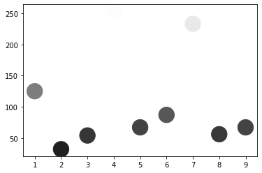

```python
from matplotlib import pyplot as plt

x = [1, 2, 3, 4, 5, 6, 7, 8, 9]
y = [125, 32, 54, 253, 67, 87, 233, 56, 67]

color = [str(item/255.) for item in y]

plt.scatter(x, y, s=500, c=color)

plt.show()
```

Ejempo 2. Asignado valores a cordenadas x, y de manera aleatoria, con el metodo random de la libreria numpy.

[figure not shown]

```python
import numpy as np
import matplotlib.pyplot as plt

# Generamos los datos ramdon con numpy
x = np.random.random(100)
y = np.random.random(100)

# definimos tamaño figura
plt.figure(figsize=(10, 5))
plt.text(0.5, 0.5, 'Prueba Scatter Plot con Mapplotlib y random', ha='center', va='center', size=20, alpha=.5)
# dibujamos el grafico scatter con matplotlib.pyplot
plt.scatter(x, y, c=y, s=500)
#plt.green()

plt.show()
```

**5. Explica cómo combinar 4 gráficos en una única figura (subplot).**

Con **subplot** podemos representar varias graficas en una misma figura:

> Representaremos 4 graficos con distintos datos (generados aleatoriamente) y representados en una misma figura, usando el metodo **subplot**. Podria ser más eficiente el código pero para efectos de entenderlo le he realizado más explicativo.

En el metodo subplot en el 3er parametro se le indica el numero del grafco a difinir. Por lo tanto antes de desplegar el grafico con plt.show(), definirmos los 4 graficos en subplots.

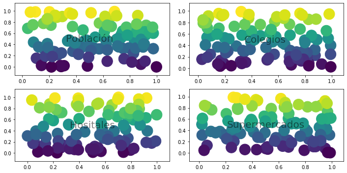

```python
import numpy as np
import matplotlib.pyplot as plt

# definimos el tamaño de la ficgura
plt.figure(figsize=(10, 5))

# Generamos los datos ramdon con numpy del primer grafico y generamos el grafico
x = np.random.random(100)
y = np.random.random(100)

plt.subplot(2, 2, 1)
plt.text(0.5, 0.5, 'Población', ha='center', va='center', size=20, alpha=.5)
plt.scatter(x, y, c=y, s=500)

# Generamos los datos ramdon con numpy del segudo grafico y generamos el grafico
x = np.random.random(100)
y = np.random.random(100)

plt.subplot(2, 2, 2)
plt.text(0.5, 0.5, 'Colegios', ha='center', va='center', size=20, alpha=.5)
plt.scatter(x, y, c=y, s=500)

# Generamos los datos ramdon con numpy del tercer grafico y generamos el grafico
x = np.random.random(100)
y = np.random.random(100)

plt.subplot(2, 2, 3)
plt.text(0.5, 0.5, 'Hositales', ha='center', va='center', size=20, alpha=.5)
plt.scatter(x, y, c=y, s=500)
#plt.gray()

# Generamos los datos ramdon con numpy del cuarto grafico y generamos el grafico
x = np.random.random(100)
y = np.random.random(100)

plt.subplot(2, 2, 4)
plt.text(0.5, 0.5, 'Supermercados', ha='center', va='center', size=20, alpha=.5)
plt.scatter(x, y, c=y, s=500)

# finalmente mostramos la figura con los 4 graficos.

plt.tight_layout()
plt.show()
```

### Segunda parte: Procesado y limpieza de datos con funciones de cadena

Primero definiremos una función para eliminar tildes. No afecta a las ñ, como lo hacen algunas funciones con unicodedata

```python
def elimina_tildes(cadena):
    a,b = 'áéíóúü','aeiouu'
    trans = str.maketrans(a,b)
    return cadena.translate(trans)
    return cadena
```

**Ahora la actividad. Dentro de la siguiente porción de código incluiremos 4 tareas, que no podemos separar dado que dependen de la lectura linea a linea del fichero.**

1. Lee el fichero proporcionado.
2. Cuenta el número de líneas del fichero (contador_linea).
3. Cuenta el número de veces que aparece el artículo «el» en el fichero (nota: elemento contiene los caracteres «el» pero no debe contar puesto que no contiene a el artículo «el».
4. Elimina las tildes del fichero (elimina_tildes) y convierta todas las letras a minúscula (linea_lower)

```python
# abre fichero texto, modalidad lectura
f = open("texto.txt", "r")

# define variables de trabajo. COntador de llineas y un array "nueva_linea" para escribir en el nuevo texto.
contador_linea = 0 # inicializa en 0
ocurrencias = 0 # inicializa en 0
nueva_linea = []

# lee el texto linea a linea
for linea in f:

    #contador de lineas del texto
    contador_linea = contador_linea + 1

    #conversor linea a minusculas.
    linea_lower = linea.lower()

    #elimina tildes
    linea_sin_tildes = elimina_tildes(linea_lower)

    #print(linea_sin_tildes)

    nueva_linea.append(linea_sin_tildes)

    #COntador de cocurrencias de articulo "el" ya en minusculas y sin tildes
    ocurrencias = ocurrencias + linea.count("el ")


f.close()
```

**5. Crea un fichero de texto con el nombre «resultado.txt» que contendrá en la primera línea el número de líneas del fichero, en la segunda línea el número de veces que aparece el artículo «el», y a partir de la tercera línea el texto original todo en minúsculas y sin tilde.**

```python
# abre un fichero de escritura
f = open('nuevo_texto.txt', 'w')

try:
    # escribe en las 2 primeras lilneas del texto:
    f.write("Numero de lineas del fichero text.txt                     : " + str(contador_linea) + "\n" )
    f.write("Numero de apariciones de alticulo -el- en fichero text.txt: " + str(ocurrencias) + "\n")

    # Procesamiento para escribir en el fichero linea a linea el array con lineas minusculas y sin tildes
    for nl in range(len(nueva_linea)):
        f.write(nueva_linea[nl])
finally:
    f.close()
```

### Tercera parte: Procesado de datos con Pandas y Numpy

El objetivo del tercer ejercicio es procesar unos registros da datos sobre municipios españoles donde almacenamos su provincia, su código postal y su población. Para realizar la práctica sigue los siguientes pasos, empleando Pandas y Numpy tanto como sea posible:Carga en el entorno el «poblacionMunicipios.csv» proporcionado por el profesor respetando las tildes y caracteres españoles.

**1.- Carga en el entorno el «poblacionMunicipios.csv» proporcionado por el profesor respetando las tildes y caracteres españoles.**

```python
import pandas as pd
# cargamos el dataset desde el fichero .csv
pob_mun_df = pd.read_csv("poblacionMunicipios.csv")
```

```python
pob_mun_df.head()
```

|  | CodProvincia | Provincia | CodMunicipio | Municipio | Poblacion |
| --- | --- | --- | --- | --- | --- |
| 0 | 1 | Araba/Álava | 1 | Alegría-Dulantzi | 2869 |
| 1 | 1 | Araba/Álava | 2 | Amurrio | 10114 |
| 2 | 1 | Araba/Álava | 3 | Aramaio | 1513 |
| 3 | 1 | Araba/Álava | 4 | Artziniega | 1861 |
| 4 | 1 | Araba/Álava | 6 | Armiñón | 231 |

```python
pob_mun_df.shape
```

```
(8117, 5)
```

**2.- Elimina las filas correspondientes a municipios sin población**

```python
pob_mun_df = pob_mun_df[pob_mun_df.Poblacion > 0]
```

```python
pob_mun_df.shape
```

```
(8116, 5)
```

**3.- Imprime el total de la población de todos los municipios**

```python
Total = pob_mun_df['Poblacion'].sum()
print ("Total de población por municipios:" + str(Total))
```

```
Total de población por municipios:47265321
```

**4.- Crea un DataFrame de Pandas donde la primera columna sean todas las provincias que aparecen en el archivo, la segunda columna el número total de habitantes por provincia, la tercera la desviación típica en el número total de habitantes por provincia y la cuarta el número total de municipios por provincia.**

```python
#provincias = pob_mun_df.groupby('Provincia')
provincias = pd.unique(pob_mun_df['Provincia'])

#provincias =  pob_mun_df.groupby('Provincia').groups()
poblacion = pob_mun_df.groupby('Provincia')['Poblacion'].sum()
municipios = pob_mun_df.groupby('Provincia')['Municipio'].count()

desviacion_tipica = 0

nuevo_df = pd.DataFrame(dict(
    provincia = provincias,
    poblacion = poblacion,
    desviacion_tipica = desviacion_tipica,
    municipio = municipios))
```

```python
nuevo_df.head()
```

| Provincia | provincia | poblacion | desviacion_tipica | municipio |
| --- | --- | --- | --- | --- |
| Albacete | Araba/Álava | 402837 | 0 | 87 |
| Alicante/Alacant | Albacete | 1943910 | 0 | 141 |
| Almería | Alicante/Alacant | 704219 | 0 | 102 |
| Araba/Álava | Almería | 322557 | 0 | 51 |
| Asturias | Ávila | 1077360 | 0 | 78 |

**5.- Carga el archivo «CP_Municipios.csv» y nuevamente poblacionMunicipios.csv .**

```python
# cargamos el dataset desde el fichero .csv
CP_municipio_df = pd.read_csv("CP_Municipios.csv")
#CP_municipio_df.head()
pob_mun_df = pd.read_csv("poblacionMunicipios.csv")
```

**6. Empleando el código de provincia y el código de municipio, cruza los dos datasets comentados hasta el momento. El resultado final debe ser un DataFrame.**

```python
new_dataframe = pd.merge(CP_municipio_df, pob_mun_df,  on=["CodProvincia", "CodMunicipio"], how="outer")
```

Desplegamos el contenido del nuevo dataframe (new_dataframe) cruzado con la clase merge.

```python
new_dataframe.head()
```

|  | CodProvincia | CodMunicipio | CP | Municipio_x | Provincia | Municipio_y | Poblacion |
| --- | --- | --- | --- | --- | --- | --- | --- |
| 0 | 1 | 1 | 1240.0 | Alegría-Dulantzi | Araba/Álava | Alegría-Dulantzi | 2869.0 |
| 1 | 1 | 1 | 1240.0 | Alegría-Dulantzi | mentira | mentira | 0.0 |
| 2 | 1 | 1 | 1193.0 | Alegría-Dulantzi | Araba/Álava | Alegría-Dulantzi | 2869.0 |
| 3 | 1 | 1 | 1193.0 | Alegría-Dulantzi | mentira | mentira | 0.0 |
| 4 | 1 | 2 | 1450.0 | Amurrio | Araba/Álava | Amurrio | 10114.0 |

**7.- Genera un CSV llamado «faltan.csv» con todos los códigos postales que estén en «CP_Municipios.csv» pero que no tengan en «poblacionMunicipios.csv» ningún municipio con el que poder cruzar. Si todo cruza correctamente el archivo «faltan.csv» estará vacío. Se puede decir que «faltan.csv» son los códigos postales que se han perdido en el cruce a la hora de considerar la población.**

```python
# modificamos el nuevo dataset solo cuando el valor Municipio este en blanco o sea no tenga ningun valor.
new_dataframe = new_dataframe[new_dataframe.Municipio_y == ""]
new_dataframe.head()

# Genera fichero faltan.cvs, con el contenido los datos del nuevo dataframe resultante del merge
new_dataframe.to_csv('faktan.csv', header=False, index=False)
```

**8.- Agrupa la información por código postal. Se quiere un DataFrame con las siguientes columnas**

- Código postal.
- Número de municipios que tienen dicho código postal asignado.
- Población: se calculará como la suma de la población de todos los municipios que incluyen a dicho código postal.
- Provincia: a la que está asignada el código postal.

```python
#provincias = pob_mun_df.groupby('Provincia')
postal = pd.unique(CP_municipio_df['CP'])


#poblacion = CP_municipio_df.groupby('CP')['Poblacion'].sum()
municipios = CP_municipio_df.groupby('CP')['Municipio'].count()


nuevo_df = pd.DataFrame(dict(
    c_postal = postal,
    c_municipios = municipios
    ))
```

```python
nuevo_df.head()
```

| CP | c_postal | c_municipios |
| --- | --- | --- |
| 548 | 1240 | 1 |
| 1001 | 1193 | 1 |
| 1002 | 1450 | 1 |
| 1003 | 1468 | 1 |
| 1004 | 1470 | 1 |